# The geometry and ecology of curved flowers and their pollinators

#### 1. The ecology of flower-pollinator curvature

> “We are beginning to understand why some hummingbird bills are long, whereas others are short, and why some hummingbird flowers are wide, whereas others are narrow. Now, why are bills of some hummingbirds and the tubes of the flowers they visit curved?” – Temeles (1996).

Pollinator specialization has major effects on macroevolutionary and biogeographic patterns (Kay and Sargent, 2009; Armbruster and Muchhala, 2009; Vamosi et al., 2018), and curvature is a component, but widespread feature of specialist systems. Therefore, to synthesize our knowledge of curved plant-pollinator systems, curvature is a concept that needs an exact definition and method of measurement. In the following section we summarize the approaches to measuring curvature within the field of bird pollination, identify strengths and shortcomings, and offer a solution with the aim of improving the precision with which curvature is measured within the field of pollination ecology. Although this review is motivated by the problem of measuring curvature in plant-hummingbird systems, the solution is general to any biological form modelled as a line curve: this case is hopefully made in the demonstration to follow.

#### 2. Summary of the literature

We searched the scientific literature for studies focusing on or considering the curvature of flowers and their pollinators - a trait commonly measured as a proxy for specialization. We make the distinction between measuring curvature (e.g. of petals) in the lateral plane versus the curvature of surfaces. While lateral images are analysed for line-curvature, images of specimens in the transverse plane are used to analyse surface (Gaussian) curvature (Nath et al., 2003; Coen and Rebocho, 2016). The methods used in the latter are relatively more complex, and perhaps because of this, comparitively well-defined. At present, surface curvature has yet to be considered in the context of pollination. However, because line and surface curvature are related mathematical concepts, it will benefit pollination research to clarify the simplest case (lines), with the goal of generating interest in related ideas including the curvature of surfaces.

The literature was sourced by querying Web of Science for a topic search of ‘curv*’ and ‘pollinat*’ or ‘flower’ or ‘corolla’ or ‘*bird’ or ‘*bee’ or ‘moth’ or ‘*fly’ i.e.

WOS Search Parameters: 1. TS=(curv* AND (pollinat* OR flower OR corolla OR *bird OR* bee OR moth OR *fly)) 2. Refined by: WEB OF SCIENCE CATEGORIES: ( EVOLUTIONARY BIOLOGY OR ECOLOGY OR PLANT SCIENCES OR ENTOMOLOGY OR ZOOLOGY OR AGRONOMY OR HORTICULTURE OR ORNITHOLOGY OR BIOLOGY OR BIODIVERSITY CONSERVATION ) 3. Timespan: All years. Indexes: SCI-EXPANDED, SSCI, A&HCI, CPCI-S, CPCI-SSH, ESCI.

An additional problem is that terminology is inconsistent between authors. This problem could be remedied by referring to the mathematical literature from which the methods were borrowed. For example, the *arc:chord* method is also called the *maxillary index*, while the *angle of deflection* method is sometimes refered to as the *angle of declension* method. In the application of the *mandibular index* one study adjusted for bill length while a subsequent study did not (Table 1). Many studies create their own terminology for the concept of arc length: the length of a curve between two points. Most studies define their own terms for measuring curvature without reference to previous studies that have done the same. This creates uncertainty about how to compare and convert metrics used between studies.

Starting in 2010, geometric morphometrics (GM) emerges in the pollination literature. GM comprises a set of protocols for quantifying and comparing shapes. This approach has steadily gained in popularity due to its mathematical rigour, reproducibility, and the appealing visual representations of shape comparisons (*e.g.* illustrations of geographic variation in flower shape Gómez et al. (2009)). We briefly outline the reasoning of a GM protocol to introduce relevant concepts, but recommend the concise and authoritative introduction by Webster and Sheets (2010). A GM protocol for a 2-D object begins by placing the specimens on an *xy* grid and assigning landmarks to locations on the specimen that are topologically or biologically homologous. A landmark is defined so that its location can be reproduced within and between samples. The set of landmarks representing the shape of an organism is a ‘landmark configuration’. In a comparative study, the samples are overlayed so that their shape information is isolated from their orientation, location, and size. This is done using a least-squares type protocol, most commonly the Generalized Procrustes Analysis (GPA). GPA-adjusted landmark configurations hereafter exist in a multidimensional shape space defined by the number of landmarks and spatial dimensions implemented. Each landmark configuration contains unique information about the specimen’s shape, and as such, occupies a unique position in the corresponding shape space. These configurations are then “projected” onto a simpler Euclidian space, similar to the reduction of a spherical Earth onto a two-dimensional map (Webster and Sheets, 2010). From here, familiar statistical procedures (*e.g.* PCA) can be performed to quantify variation in landmark configurations (shape) between samples.

This is giant leap forward for morphological studies because GM is a complete protocol for measuring, quantifying, and comparing shapes with high precision, as well as the covariation of these shapes with ecological variables of interest. Because GM has a traceable mathematical lineage (Bookstein, 1997), its vernacular is well-defined and used consistently between practitioners. The limitation of GM in quantifying curvature is that this method is concerned with analyzing configurations of landmarks, *i.e.* the entirety of a shape summarized as a set of *xy* coordinates. Once the specimen has been reduced to a landmark configuration, it exists as a point in shape space. Parsing segments of landmark configurations for separate analyses (*e.g.* for curvature) is not currently part of the geometric morphometrics toolkit. Therefore, studies that have used this technique to analyse biological forms are able to compare shapes in their entirety, but are ultimately limited to making descriptive statements about how segments of shapes appear to have different curvatures (*e.g.* Berns and Adams, 2013).

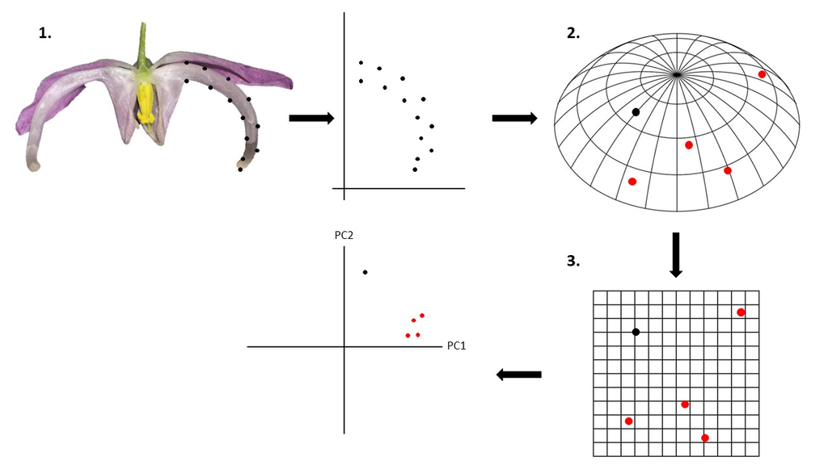

Figure 2. Overview of a geometric morphometrics protocol. 1. Landmarks and semi-landmarks are assigned to a specimen. Each landmark is assigned an *xy* coordinate. 2. For each specimen a configuration of landmarks exists as a single point in a non-Euclidian shape space (abstracted here as a sphere segment). Red points represent landmark configurations from other specimens. 3. Shape data is projected onto a Euclidian plane – a tangent space approximation. This allows statistical analyses of shape variation (e.g. principal components analysis).

#### 3. What is curvature?

Reviewing the literature leads us to ask, “what is curvature?”. Turning to the field of geometry, we find several related definitions, resulting from a history of independent mathematical derivations (reviewed in Coolidge, 1952; Bardini and Gianella, 2016). Here, we follow the conventions of Casey (1996) and Rutter (2000), and present a definition relevant to the problem of analyzing biological shapes.

Intuitively, when a line deviates from being straight we say it is curved. Then, at any given point, the extent to which a line is not straight is its curvature. More technically, a line deviates from being straight when its first derivative - the tangent - changes direction. Therefore, curvature can be thought of as the rate at which the tangent is changing direction as we move across the curve (Figure 3). On a straight line, the tangent has the same direction everywhere and its rate of change (curvature) will be zero. On a curve, the tangent changes directions from point to point and will have some degree of curvature.

We can formalize the above concepts as follows:

An ordinary function of the form $y=f(x)$ allows one value of $y$ at a single $x$ position. However, biological curves are better described by parametric fuctions that allow the curve to have multiple $y$ values at a single value of $x$ (*e.g.* spirals). Parametric functions use a ‘hidden’ variable that determines the values of $x$ and $y$ independently. For example, if we take the hidden parameter to be the arc length $s$ of a curve, $(x, y)$ will be determined by our position $s_i$ on the curve. We can express the relationship between arc length $s$ and position $(x, y)$ as a parametric equation:

$$r(s) = \left[\begin{array}
{rrr}
x(s) \\
y(s) \\
\end{array}\right]$$

Where $r(s_i)$ indicates that our position $r_i = (x_i, y_i)$ on the curve is determined by the length of the segment $s_i$. Although we could parameterize a curve by any arbitrary variable, arc length is a convienient parameter because it allows us to move along the curve at even increments of $\Delta s$. This proves useful when taking repeated, equally-spaced measurements along a curve, such as curvature.

If we are interested in the derivative properties of our arc-length parameterized function, we can differentiate $r(s)$ with respect to arc length $s$ as

$\lim\limits_{\Delta s \to 0} \frac{\Delta r}{\Delta s} = \frac{dr}{ds} = T$

The resultant tangent function $T = \frac{dr}{ds}$ is the first derivative of the parametric equation $r(s)$. The tangent $T_i$ contains information about the direction of the curve at position $r(s_i)$ that we will use to calculate curvature.

At the beginning of this section we defined curvature ($\kappa$) as the rate at which the tangent is changing direction. We can now formalize this by differentiating $T$ with respect to arc length:

$\kappa = \frac{dT}{ds}$

When the tangent is placed into a cartesian plane its direction is related to the angle $\phi$ formed with the $x$-axis. We can then re-state curvature at a single point as

$\kappa = \frac{d\phi}{ds}$

This definition provides an intuitive unit of measurement for reporting curvature: degrees of rotation per unit arc length (Figure 4). For example, if arc length has been measured in millimeters, we would report its curvature as degrees per millimeter $\phi \cdot mm^{-1}$. Framed this way curvature is a measurement of rotation per distance. This notion of curvature differs from the concepts reviewed in the previous section. Here, curvature is a property of every point along a curve whereas in previous definitions, curvature is a single property of an entire shape. However, it is just as useful to summarize the *total curvature* (Milnor, 1954) of a specimen. To do this, we can sum the individual curvature measurements made across the curve. This is calculated as:

$\kappa_{total} = \int_{0}^{s} \kappa$ $ds$

Units for *total curvature* are no longer expressed as $\phi \cdot mm^{-1}$ because we are not measuring curvature at a single point. Instead we are summarizing tangent rotations across the curve, expressed simply as $\phi$.

To account for size variation between specimens, we propose using *total adjusted curvature*, that is, total curvature divided by arc length

$\kappa_{adj} = \frac{\kappa_{total}}{s}$

Units for $\kappa_{adj}$ are expressed as $\phi \cdot mm^{-1}$. *Total adjusted curvature* also represents mean curvature of the curve.

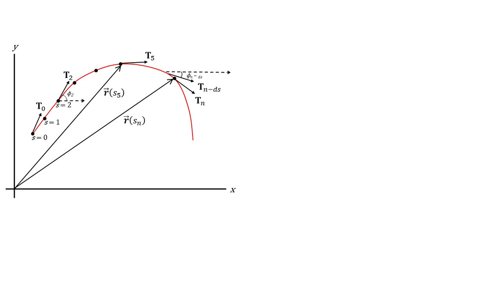

#### 4. A proposed protocol for measuring curvature

As illustrated in the methodology review, our current protocols for measuring flower-pollinator curvature lack a conceptual unity. In each method, curvature takes on a new meaning. Therefore, there are two main advantages of the curvature definition described above. First, curvature becomes a local property of the tissue or organ under study. This means that shape information is gathered at every point along the curve and can be examined and compared to other points within or between specimens. This differs from previous methods that take curvature as a total property of the entire curve. In these measurements curvature cannot be parsed into smaller elements. Second, because the revised definition is explicitly adapted from the field of differential geometry, we benefit from citeable geometric concepts that allow us to be clear about what we mean by ‘curvature’.

In order to apply the above definition of curvature, a biological organ or tissue needs to be reduced to a continuous function. We propose a workflow as illustrated in Figure 4. Cosgrove (1990) uses an analogous approach to study the development of cucumber hypocotyls. By fitting cubic splines to hand-marked seedlings, curvature was computed using the same definition as above. However, since Cosgrove (1990), the entire field of landmark-based geometric morphometrics has unfolded (reviewed in Adams et al., 2013). This rigorous, reproducible toolkit has been used occasionally in pollination ecology, but has not yet been leveraged to calculate curvature (Table 1). Terral et al (2004) use these tools to digitally landmark olive stones and fit polynomials to the landmarks: synthesizing the concepts of Cosgrove (1990) and Terral (2004) produces a modernized method for fitting curves and computing curvature from biological forms (Figure 4)

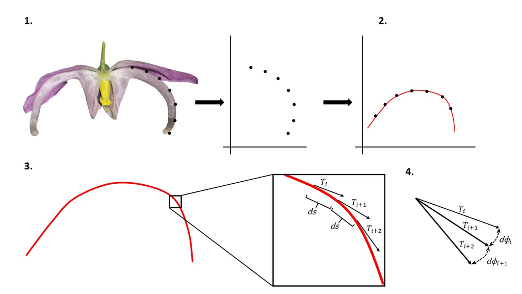

Figure 4: Proposed protocol for measuring curvature. 1. A petal of *Epimedium violaceum* is landmarked and rotated. 2. A polynomial curve is fitted to the landmarks. 3. Curvature is calculated as the rate of change of the tangent vector at every point along the curve. Total curvature can be calculated by the methods outlined in Section 3.

#### 5. Proof of concept: A study of the development of curvature in *Epimedium*

Flowering stage data was fragmented and staggered because of censoring, i.e. due to tracking flowers after their initial budding stage, or flowers that had succumb to herbivory or weather after several days of measurement. Therefore, stage data was aligned by using a multiple sequence alignment protocol (ClustalW implemented in `msa` v.3.9) with a neutral (identity) substitution matrix. Gap opening was prohibited. By aligning phenological data within species, a consensus stage sequence was calculated and used to estimate flower age where observations were censored. Once aligned, these data represent the ‘developmental dataset’.

To measure curvature, a separate set of flowers were sampled haphazardly and preserved in 70% ethanol. Preserved flowers were later transferred to a glass slide and imaged in the lateral view using a stereo microscope at 0.63x (Zeiss Stemi 508 with Axiocam 301). Specimens that did not fit within the field of view were imaged in halves and the images joined using the Stitching Plugin in the Fiji distribution of ImageJ2 (Preibisch et al., 2009; Rueden et al., 2017).

Landmark files (.tps) were imported into R using `Momocs` v.1.3.0 (Bonhomme et al., 2014). Polynomial functions were regressed to the landmark coordinates for each specimen using `Momocs` - we chose polynomials of the third degree based on the recommendations of Rolhf (1990). Arc length was calculated from bounded polynomial functions using `pracma` v.2.2.5 (Borchers, 2019). Curvature, as defined in the previous section, was computed using a custom function modified from the `maxcurv()` function of the `soilphysics` package v.3.1 (Silva and Lima, 2017). All custom functions used in this analysis are available as an R package `curvy` hosted at github.com/mannfred/curvy. R scripts used in this analysis are hosted at github.com/mannfred/epidmedium. These data represent the ‘curvature dataset’.

Because the second set of flowers were sampled opportunistically after the developmental study, age was inferred by outer sepal size. First, the developmental data was used to model size and age as a logistic function using the ``drc` v.3.0.1 package in R (Ritz et al., 2015). Then, age was inferred for the curvature data by inputing size information into the logistic model.

Results:

In *E. grandiflorum* we identified three distinct stages of development (Tukey’s HSD: p<0.01). The first stage (“G”) is defined as the initiation and growth of the bud until the petals begin to separate (“T” stage). At the “T” stage nectar begins accumilating in the spurs. Anthesis takes place during the “A” stage at which point the flower opening may increase in size and anthers dehisce. In *E. koreanum* and *E. violaceum* we detected another distinct “C” stage in the early stage of bud development. At this stage the petals are shorter in length than the sepals that envelop them - the “G” stage begins when the petals overtake the surrounding sepals in length.

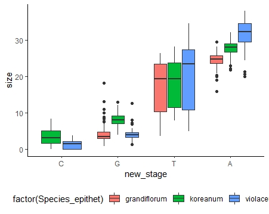

Figure 5: Comparison of developmental stages. Size is in mm. Tukey’s HSD: p<0.01 for all within-species comparisons

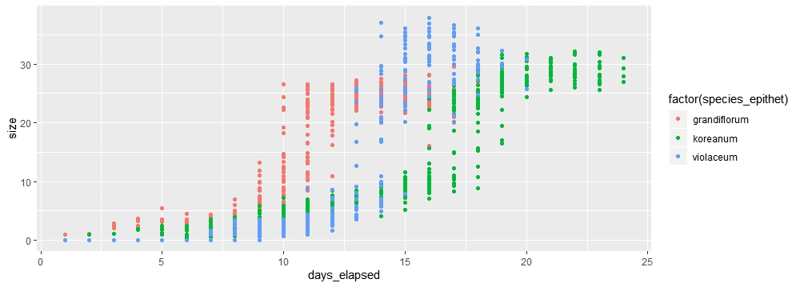

Figure 9: Logistic growth of Epimedium flowers

*E. koreanum* is more curved at initial stages of development:

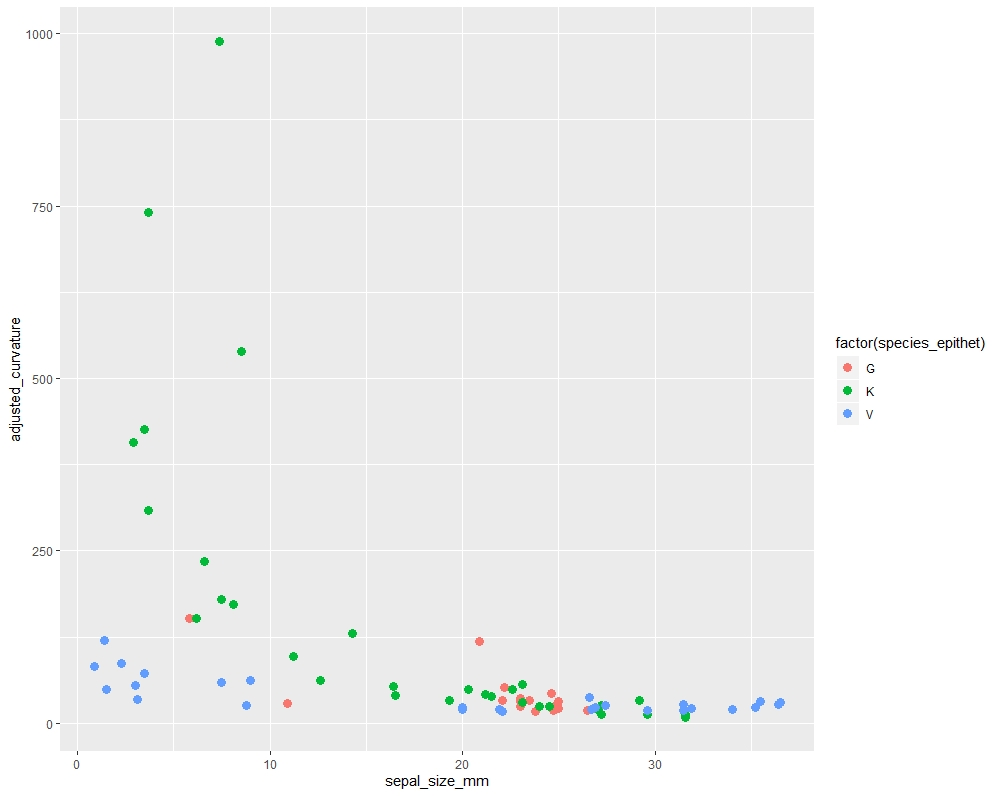

Figure 10: size vs curvature

*E. koreanum* is more curved at initial stages of development:

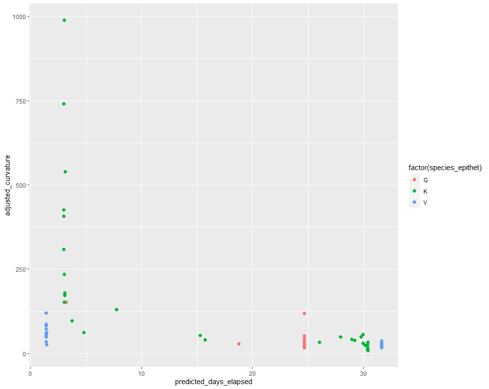

Figure 11: elapsed days vs curvature

Table 1: Summary of literature reviewed for the role of curvature in plant-pollinator systems.

[output not shown]

Table 3: Elapsed days per stage for three Epimedium species.

| Species | C.Stage | G.Stage | T.Stage | A.Stage |
| --- | --- | --- | --- | --- |
| E. grandiflorum | NA | 7.01 +/- 0.45 days | 10.9 +/- 0.20 days | 14.7 +/- 0.20 days |
| E. koreanum | 8.31 +/- 0.40 days | 14.3 +/- 0.20 days | 17.1 +/- 0.20 days | 20.6 +/- 0.30 days |
| E. violaceum | 8.27 +/- 0.40 days | 12.0 +/- 0.20 days | 14.1 +/- 0.20 days | 16.7 +/- 0.30 days |

# References

Adams, D.C., Rohlf, F.J., and Slice, D.E. (2013). A field comes of age: Geometric morphometrics in the 21st century. Hystrix *24*, 7.

Armbruster, W.S., and Muchhala, N. (2009). Associations between floral specialization and species diversity: Cause, effect, or correlation? Evolutionary Ecology *23*, 159.

Baldwin, S.P., Oberholser, H.C., and Worley, L.G. (1931). Measurements of birds (Cleveland Museum of Natural History).

Bardini, G., and Gianella, G.M. (2016). A historical walk along the idea of curvature, from Newton to Gauss passing from Euler. International Mathematical Forum *11*, 259–278.

Bell, J. (1956). 2619. Tangent, chord theorem. The Mathematical Gazette *40*, 211–212.

Berns, C.M., and Adams, D.C. (2010). Bill shape and sexual shape dimorphism between two species of temperate hummingbirds: Black-Chinned hummingbird (*Archilochus alexandri*) and Ruby-Throated hummingbird (*Archilochus colubris*). The Auk *127*, 626–635.

Berns, C.M., and Adams, D.C. (2013). Becoming different but staying alike: Patterns of sexual size and shape dimorphism in bills of hummingbirds. Evolutionary Biology *40*, 246–260.

Blüthgen, N., Menzel, F., and Blüthgen, N. (2006). Measuring specialization in species interaction networks. BMC Ecology *6*, 9.

Bonhomme, V., Picq, S., Gaucherel, C., and Claude, J. (2014). Momocs: Outline analysis using r. Journal of Statistical Software *56*, 1–24.

Bookstein, F.L. (1997). Morphometric tools for landmark data: Geometry and biology (Cambridge University Press).

Borchers, H.W. (2019). Pracma: Practical numerical math functions. R package version 2.2.5.

Casey, J. (1996). Exploring curvature (Braunschweig, Germany: Friedr. Vieweg & Sohn Verlagsgesellschaft mbH).

Coen, E., and Rebocho, A.B. (2016). Resolving conflicts: Modeling genetic control of plant morphogenesis. Developmental Cell *38*, 579–583.

Coolidge, J.L. (1952). The unsatisfactory story of curvature. The American Mathematical Monthly *59*, 375–379.

Cosgrove, D.J. (1990). Rapid, bilateral changes in growth rate and curvature during gravitropism of cucumber hypocotyls: Implications for mechanism of growth control. Plant, Cell & Environment *13*, 227–234.

Dehling, D.M., Töpfer, T., Schaefer, H.M., Jordano, P., Böhning-Gaese, K., and Schleuning, M. (2014). Functional relationships beyond species richness patterns: Trait matching in plant–bird mutualisms across scales. Global Ecology and Biogeography *23*, 1085–1093.

Gómez, J., Perfectti, F., Bosch, J., and Camacho, J. (2009). A geographic selection mosaic in a generalized plant–pollinator–herbivore system. Ecological Monographs *79*, 245–263.

Graham, C.H., Parra, J.L., Rahbek, C., and McGuire, J.A. (2009). Phylogenetic structure in tropical hummingbird communities. Proceedings of the National Academy of Sciences *106*, 19673–19678.

Grant, V. (1949). Pollination systems as isolating mechanisms in angiosperms. Evolution *3*, 82–97.

Hainsworth, F.R. (1973). On the tongue of a hummingbird: Its role in the rate and energetics of feeding. Comparative Biochemistry and Physiology Part A: Physiology *46*, 65–78.

Kay, K.M., and Sargent, R.D. (2009). The role of animal pollination in plant speciation: Integrating ecology, geography, and genetics. Annual Review of Ecology, Evolution, and Systematics *40*, 637–656.

Lagomarsino, L.P., and Muchhala, N. (2019). A gradient of pollination specialization in three species of bolivian centropogon. American Journal of Botany *106*, 633–642.

Maglianesi, M.A., Blüthgen, N., Böhning-Gaese, K., and Schleuning, M. (2014). Morphological traits determine specialization and resource use in plant–hummingbird networks in the neotropics. Ecology *95*, 3325–3334.

Maglianesi, M.A., Blüthgen, N., Böhning-Gaese, K., and Schleuning, M. (2015). Functional structure and specialization in three tropical plant–hummingbird interaction networks across an elevational gradient in costa rica. Ecography *38*, 1119–1128.

Milnor, J. (1954). On total curvatures of closed space curves. Mathematica Scandinavica *1*, 289–296.

Minnaar, C., Jager, M. de, and Anderson, B. (2019). Intraspecific divergence in floral-tube length promotes asymmetric pollen movement and reproductive isolation. New Phytologist.

Nath, U., Crawford, B.C., Carpenter, R., and Coen, E. (2003). Genetic control of surface curvature. Science *299*, 1404–1407.

Ollerton, J. (2017). Pollinator diversity: Distribution, ecological function, and conservation. Annual Review of Ecology, Evolution, and Systematics *48*, 353–376.

Preibisch, S., Saalfeld, S., and Tomancak, P. (2009). Globally optimal stitching of tiled 3D microscopic image acquisitions. Bioinformatics *25*, 1463–1465.

Ritz, C., Baty, F., Streibig, J.C., and Gerhard, D. (2015). Dose-response analysis using R. PloS One *10*, e0146021.

Robertson, C. (1889). Flowers and insects. II. Botanical Gazette *14*, 172–178.

Rohlf, F.J. (2015). The tps series of software. Hystrix *26*.

Rolhf, F.J. (1990). Fitting curves to outlines. In Proceedings of the Michigan Morphometrics Workshop, F.J. Rolhf, and F.L. Bookstein, eds. (Ann Arbor, MI: University of Michigan Museum of Zoology), pp. 177–188.

Rueden, C.T., Schindelin, J., Hiner, M.C., DeZonia, B.E., Walter, A.E., Arena, E.T., and Eliceiri, K.W. (2017). ImageJ2: ImageJ for the next generation of scientific image data. BMC Bioinformatics *18*, 529.

Rutter, J.W. (2000). Geometry of curves (Boca Raton, FL: CRC Press, Taylor; Francis Group).

Scott-Elliot, G. (1890). Ornithophilous flowers in south africa. Annals of Botany *4*, 265–280.

Silva, A.R. da, and Lima, R.P. de (2017). Determination of maximum curvature point with the r package soilphysics. International Journal of Current Research *9*, 45241–45245.

Sonne, J., Zanata, T.B., Martı́n González, A.M., Cumbicus Torres, N.L., Fjeldså, J., Colwell, R.K., Tinoco, B.A., Rahbek, C., and Dalsgaard, B. (2019). The distributions of morphologically specialized hummingbirds coincide with floral trait matching across an andean elevational gradient. Biotropica *51*, 205–218.

Stearn, W.T. (2002). The genus *Epimedium* and other herbacious Berberidaceae including the genus *Podophyllum* (Portland, OR: Timber Press, Inc.).

Stiles, F.G. (1975). Ecology, flowering phenology, and hummingbird pollination of some costa rican heliconia species. Ecology *56*, 285–301.

Stiles, F.G. (2004). Phylogenetic constraints upon morphological and ecological adaptation in hummingbirds (trochilidae): Why are there no hermits in the paramo. Ornitologia Neotropical *15*, 191–198.

Temeles, E.J. (1996). A new dimension to hummingbird-flower relationships. Oecologia *105*, 517–523.

Temeles, E.J., Koulouris, C.R., Sander, S.E., and Kress, W.J. (2009). Effect of flower shape and size on foraging performance and trade-offs in a tropical hummingbird. Ecology *90*, 1147–1161.

Terral, J.-F., Alonso, N., Capdevila, R.B. i, Chatti, N., Fabre, L., Fiorentino, G., Marinval, P., Jordá, G.P., Pradat, B., Rovira, N., et al. (2004). Historical biogeography of olive domestication (olea europaea l.) as revealed by geometrical morphometry applied to biological and archaeological material. Journal of Biogeography *31*, 63–77.

Vamosi, J.C., Magallón, S., Mayrose, I., Otto, S.P., and Sauquet, H. (2018). Macroevolutionary patterns of flowering plant speciation and extinction. Annual Review of Plant Biology *69*, 685–706.

Webster, M., and Sheets, H.D. (2010). A practical introduction to landmark-based geometric morphometrics. The Paleontological Society Papers *16*, 163–188.